# The Knowledge Gap - The Global State of HIV Youth Knowledge

Author

Andre Martinez

```python
from google.colab import drive
drive.mount("/content/drive")
```

# **1. Introduction - The HIV Youth Literacy Problem**

More than **40 million people** around the globe live with HIV and more than **600,000** die every year because of it.

This report takes a closer look at the data global patterns in youth HIV knowledge around prevention, exploring:

1. Youth HIV knowledge around the world
2. Difference in knowledge between young men and women
3. The evolution of youth HIV knowledge through the years
4. The relationship with HIV knowledge and prevention

## **1.1 Code & Libraries**

The following are code snippets for setting up data for analysis and to generate visual representations.

```python
import polars as pl
import geopandas as gpd
from plotnine import *
```

```python
# Main Indicator Dataset (HIV Youth Knowledge)
hiv_knowledge = pl.read_csv("/content/unicef_indicator_1_clean.csv")

# Complementary Dataset (HIV Youth Testing)
hiv_testing = pl.read_csv("/content/UNICEF_HIV_TEST.csv")
```

```python
# Get the most recent year's HIV youth knowledge per country
latest_avg_knowledge = (
hiv_knowledge
    .filter(pl.col("year") == pl.col("year").max().over("alpha_3_code"))
    .group_by("alpha_3_code", "country")
    .agg(pl.col("obs_value_percentage").mean().alias("avg_hiv_knowledge"))
)

# Get the most recent year's HIV youth testing per country from the complementary file
latest_avg_testing = (
   hiv_testing
    .filter(pl.col("year") == pl.col("year").max().over("alpha_3_code"))
    .group_by("alpha_3_code")
    .agg(pl.col("obs_value_percent").mean().alias("avg_hiv_testing"))
)

# Join on alpha_3_code to link HIV youth knowledge with HIV youth testing data
combined_data = (
    latest_avg_knowledge
    .join(
      latest_avg_testing,
        on='alpha_3_code',
        how='left'
    )
)
```

```python
# Create the UNICEF regions for grouping
region_mapping = {
    "Sub-Saharan Africa": ["BDI", "BEN", "COG", "COM", "UGA", "NGA", "NAM", "ZAF", "KEN", "ETH", "TZA", "LSO", "MDG", "GAB", "GIN", "GMB", "GHA", "COD", "ZWE", "MWI", "MRI", "MRT", "RWA", "ZMB", "AGO", "MOZ", "BFA", "MLI", "SEN", "SLE", "STP", "SWZ", "TCD", "TGO", "SOM", "CIV", "CMR"],
    "South Asia": ["AFG", "BGD", "BTN", "IND", "MDV", "NPL", "PAK", "LKA"],
    "Middle East and North Africa": ["DZA", "BHR", "DJI", "EGY", "IRN", "IRQ", "JOR", "KWT", "LBN", "LBY", "MAR", "OMN", "QAT", "SAU", "SDN", "SYR", "TUN", "ARE", "YEM"],
    "Latin America and Caribbean": ["ARG", "BHS", "BRB", "BLZ", "BOL", "BRA", "CHL", "COL", "CRI", "CUB", "DOM", "ECU", "GUY", "SLV", "GTM", "HTI", "HND", "JAM", "MEX", "NIC", "PAN", "PRY", "PER", "URY", "VEN"],
    "East Asia and Pacific": ["AUS", "KHM", "CHN", "FJI", "IDN", "JPN", "KIR", "PRK", "KOR", "LAO", "MYS", "MHL", "FSM", "MNG", "MMR", "NRU", "NZL", "PLW", "PNG", "PHL", "WSM", "SGP", "SLB", "THA", "TLS", "TON", "TUV", "VUT", "VNM"],
    "Europe and Central Asia": ["ALB", "AND", "ARM", "AUT", "AZE", "BLR", "BEL", "BIH", "BGR", "HRV", "CYP", "CZE", "DNK", "EST", "FIN", "FRA", "GEO", "DEU", "GRC", "HUN", "ISL", "IRL", "ITA", "KAZ", "KGZ", "LVA", "LIE", "LTU", "LUX", "MLT", "MCO", "MNE", "NLD", "MKD", "NOR", "POL", "PRT", "MDA", "ROU", "RUS", "SMR", "SRB", "SVK", "SVN", "ESP", "SWE", "CHE", "TJK", "TUR", "TKM", "UKR", "GBR", "UZB"]
}

# Flatten the dictionary into a list of tuples using list comprehension
metadata_rows = [(country, region) for region, countries in region_mapping.items() for country in countries]

# Convert to a Polars DataFrame
region_mapping_df = pl.DataFrame(metadata_rows, schema=["alpha_3_code", "UNICEF_Region"], orient="row")

# Join the region data with our previous combined data
combined_knowledge_testing_region = combined_data.join(region_mapping_df, on="alpha_3_code", how="left")

# 5. Convert to pandas for plotnine
scatter_data_pd = combined_knowledge_testing_region.to_pandas()
```

```python
# Prepare HIV knowledge data per gender
# Get the latest year per country for HIV knowledge
latest_knowledge_sex = (
    hiv_knowledge
    .filter(pl.col("year") == pl.col("year").max().over("alpha_3_code"))
)

# Join with our regions
mapped_knowledge_sex = latest_knowledge_sex.join(region_mapping_df, on="alpha_3_code", how="inner")

# Group by both Region and Sex, then calculate the average percentage
region_avg_knowledge_sex = (
    mapped_knowledge_sex
    .group_by("UNICEF_Region", "sex")
    .agg(pl.col("obs_value_percentage").mean().alias("avg_knowledge"))
)
```

```python
# Create yearly youth HIV knowledge dataset

# 1. Calculate the yearly average HIV knowledge per sex
yearly_avg_knowledge_sex = (
    hiv_knowledge
    .filter(pl.col("sex").is_in(["Male", "Female"]))
    .drop_nulls(subset=["year", "obs_value_percentage"])
    .group_by("year", "sex")
    .agg(pl.col("obs_value_percentage").mean().alias("avg_knowledge"))
    .select(["year", "sex", "avg_knowledge"])
)

# 2. Calculate the overall global average and label it
yearly_global_avg = (
    hiv_knowledge
    .drop_nulls(subset=["year", "obs_value_percentage"])
    .group_by("year")
    .agg(pl.col("obs_value_percentage").mean().alias("avg_knowledge"))
    .with_columns(pl.lit("Global Average").alias("sex"))
    .select(["year", "sex", "avg_knowledge"])
)

# 3. Stack them together into one dataset
combined_time_data = pl.concat([yearly_sex_avg, yearly_global_avg]).sort("year")
combined_time_pd = combined_time_data.to_pandas()
```

## # **2. Youth HIV Knowledge - A Global View**

**Health is a human right.**

Access to HIV prevention tools, education, and services protects not only people’s health but also their rights. It’s key to stopping new infections and saving lives.

Yet, **only 27% of young people** (15-24 years old) around the world have comprehensive and correct knowledge of HIV, including prevention and misconceptions about its transmission.

In some countries, **less than 1 out of 10 young people** can correctly identify common misconceptions about HIV or how to prevent its sexual transmission, leading to stigma and lack of prevention.

## **2.1. Global Comprehensive HIV Youth Knowledge By Country**

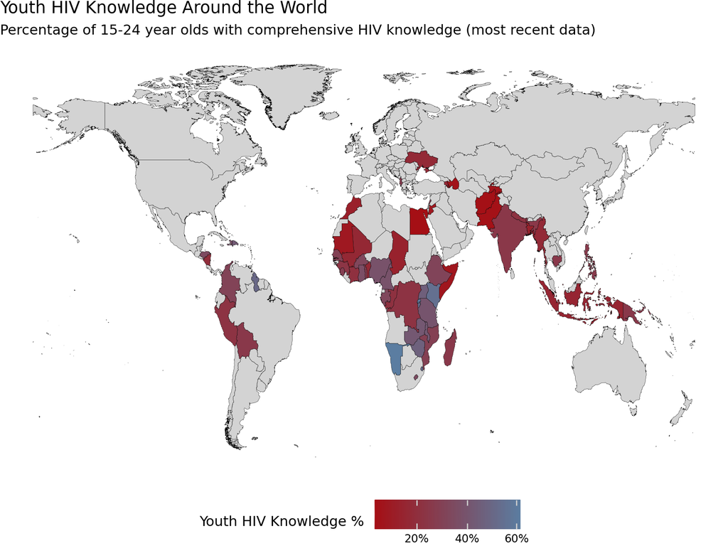

```python
# Create Youth HIV Knowledge Map Visualisation

# 1. Load world geometries from Natural Earth shapefile
world = gpd.read_file("https://public.opendatasoft.com/api/explore/v2.1/catalog/datasets/world-administrative-boundaries/exports/shp")

# 2. Merge with our data using ISO 3-letter codes
map_df = latest_avg_knowledge[['alpha_3_code', 'avg_hiv_knowledge']].to_pandas()
world_merged = world.merge(map_df, left_on="iso3", right_on="alpha_3_code", how="outer")
world = world[world.name != "Antarctica"]

# 3. Build the map with the custom gradient

world_map_red = (
    ggplot(world_merged)
    + geom_map(aes(fill="avg_hiv_knowledge"), color="black", size=0.1)
    + scale_fill_gradient(
        low="#a50f15",
        high="#5B7DA1",
        na_value="lightgrey",
        labels=lambda l: [f"{v:.0%}" for v in l],
        guide=guide_colorbar()
        )
    + theme_void()
    + labs(
        title="Youth HIV Knowledge Around the World",
        subtitle="Percentage of 15-24 year olds with comprehensive HIV knowledge (most recent data)",
        fill="Youth HIV Knowledge %"
    )
    + theme(figure_size=(8, 6), legend_position='bottom', legend_direction='horizontal')
)

world_map_red
```

**Afghanistan, Egypt and Pakistan** registered the lowest levels of youth HIV literacy among the young population, with less than 5% of young men and women showing comprehensive knowledge about the disease.

## **2.2. The Evolution of HIV Knowledge Through the Years**

The time-series chart shows the global HIV knowledge evolution in young people, as well as the average per gender.

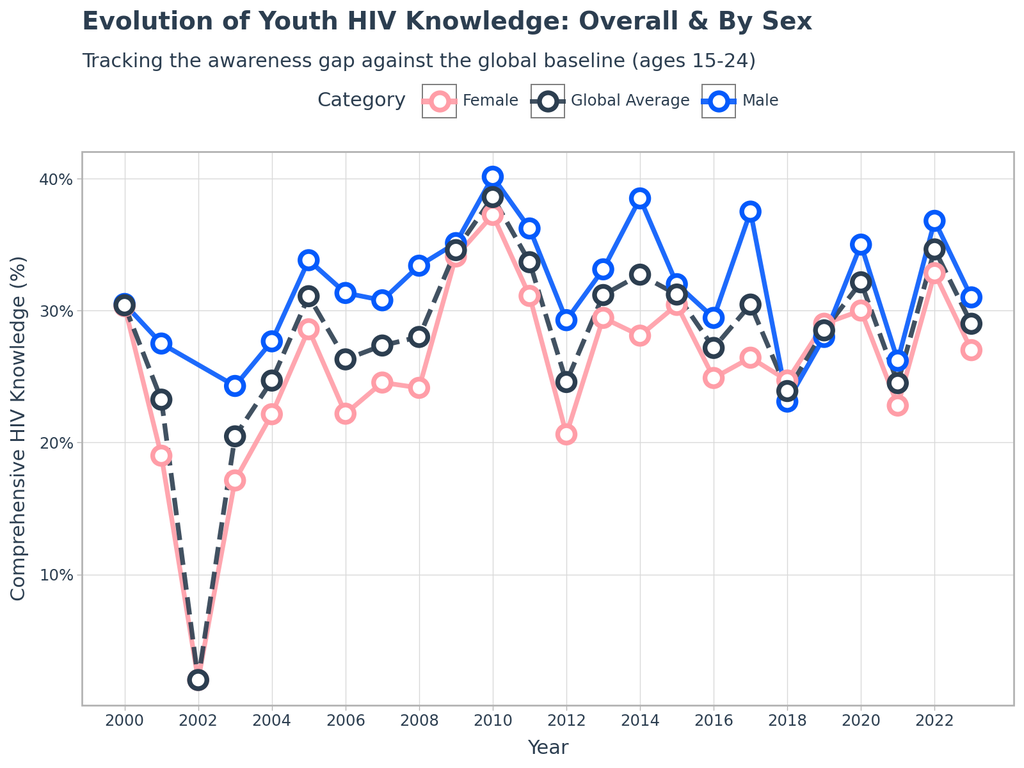

```python
# 4. Create Youth HIV Knowledge Master Time-Series Visualisation
master_time_chart = (
    ggplot(combined_time_pd, aes(x="year", y="avg_knowledge", color="sex", group="sex", linetype="sex")) +
    geom_line(size=1.5, alpha=0.9) +
    geom_point(size=4, fill="white", stroke=1.5) +
    scale_y_continuous(labels=lambda l: [f"{v:.0%}" for v in l]) +
    scale_x_continuous(breaks=range(int(combined_time_pd['year'].min()), int(combined_time_pd['year'].max()) + 1, 2)) +
    scale_color_manual(values={"Female": "#FF9DA7", "Male": "#045AFC", "Global Average": "#2c3e50"}) +
    scale_linetype_manual(values={"Female": "solid", "Male": "solid", "Global Average": "dashed"}) +

    theme_light() +
    labs(
        title="Evolution of Youth HIV Knowledge: Overall & By Sex",
        subtitle="Tracking the awareness gap against the global baseline (ages 15-24)",
        x="Year",
        y="Comprehensive HIV Knowledge (%)",
        color="Category",
        linetype="Category"
    ) +
    theme(
        figure_size=(8, 6),
        text=element_text(family="sans-serif", color="#2c3e50"),
        plot_title=element_text(weight="bold", size=14, margin={'b': 10}),
        panel_grid_minor=element_blank(),
        legend_position="top"
    )
)

master_time_chart
```

# **3. Gender: An Important Role in HIV Education and Prevention**

As seen below in the bar chart comparing average HIV knowledge between young men and women in all regions, except for Europe and Central Asia, young women report **lower HIV prevention knowledge than young men**.

## **3.1. Global HIV Knowledge per Gender and Region**

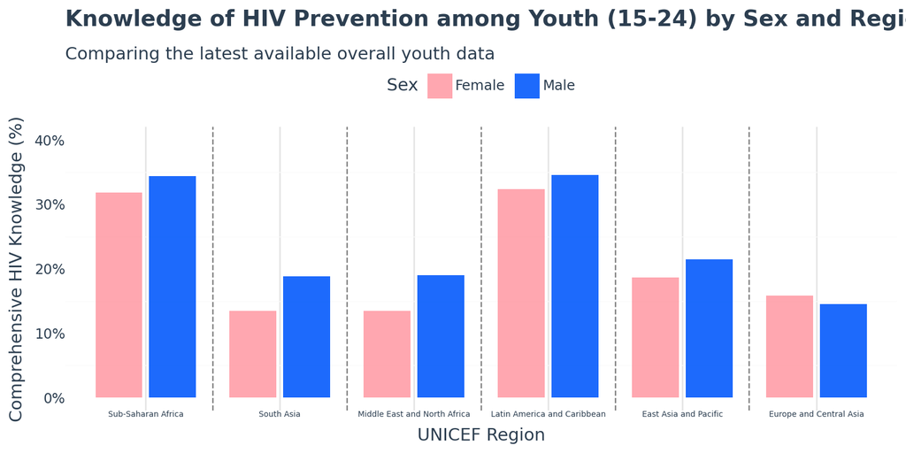

```python
# Create Youth HIV Knowledge per Sex Bar Chart Visualisation

# 1. Convert to pandas for plotting
bar_data_pd = region_avg_knowledge_sex.to_pandas()

bar_data_pd['formatted_label'] = bar_data_pd['avg_knowledge'].apply(lambda x: f"{x:.0%}")

# Get the intended order of regions from the region_mapping
ordered_regions = list(region_mapping.keys())

bar_data_pd['UNICEF_Region'] = pd.Categorical(
    bar_data_pd['UNICEF_Region'],
    categories=ordered_regions,
    ordered=True
)

num_regions = len(bar_data_pd['UNICEF_Region'].unique())
vline_xintercepts = [i + 1.5 for i in range(num_regions - 1)]

# 2. Build the Grouped Bar Chart
bar_chart = (
    ggplot(bar_data_pd, aes(x="UNICEF_Region", y="avg_knowledge", fill="sex")) +
    geom_col(position=position_dodge(width=0.8), width=0.7, alpha=0.9) +
    geom_vline(xintercept=vline_xintercepts, linetype="dashed", color="gray", size=0.5) +
    scale_y_continuous(labels=lambda l: [f"{v:.0%}" for v in l], limits=(0, .4)) +
    scale_fill_manual(values={"Female": "#FF9DA7", "Male": "#045AFC"}) +

    theme_minimal() +
    labs(
        title="Knowledge of HIV Prevention among Youth (15-24) by Sex and Region",
        subtitle="Comparing the latest available overall youth data",
        x="UNICEF Region",
        y="Comprehensive HIV Knowledge (%)",
        fill="Sex"
    ) +
    theme(
        figure_size=(8, 4),
        text=element_text(family="sans-serif", color="#2c3e50"),
        plot_title=element_text(weight="bold", size=14, margin={'b': 10}),
        panel_grid_major_y=element_blank(),
        legend_position="top",
        axis_text_x=element_text(angle=0, hjust=0.5, size=5)
    )
)

bar_chart
```

In 8 out of the 10 countries with the highest HIV knowledge gap between young men and women, **young women** are the ones being left behind.

# **4. The Importance of Youth HIV Knowledge**

## **4.1. Relationship Between HIV Knowledge and Getting Tested**

Prevention empowers, protects and leads to **action**! There is a positive correlation between a country’s HIV literacy among the young population and the percentage of young people that have taken an HIV test. It’s essential that countries prioritise educating their youth to prevent transmission and for them to regularly get tested.

**Interactive HIV Knowledge vs. Testing**

```python
# Build the Scatterplot Visualisation

# Use the scatter_data_pd dataframe previously built

interactive_scatter = px.scatter(
    scatter_data_pd,
    x="avg_hiv_knowledge",
    y="avg_hiv_testing",
    color="UNICEF_Region",
    hover_name="country",
    trendline="ols",
    trendline_scope="overall",
    trendline_color_override="#95a5a6",
    color_discrete_sequence=px.colors.qualitative.Dark2,

    labels={
        "avg_hiv_knowledge": "Comprehensive HIV Knowledge (%)",
        "avg_hiv_testing": "Tested for HIV in past 12 months (%)",
        "UNICEF_Region": "UNICEF Region"
    },
    title="<b>Knowledge Translates to Action: HIV Awareness vs. Testing</b><br><sup>Correlating overall youth data (15-24) across global regions</sup>"
)

interactive_scatter.update_layout(
    plot_bgcolor="white",
    font=dict(family="sans-serif", color="#2c3e50"),
    xaxis=dict(tickformat=".0%", showgrid=True, gridcolor="#ecf0f1", zeroline=False),
    yaxis=dict(tickformat=".0%", showgrid=True, gridcolor="#ecf0f1", zeroline=False),
    legend=dict(title_font_weight="bold", bgcolor="rgba(255,255,255,0.8)")
)

for trace in interactive_scatter.data:
    if trace.mode == 'markers':
        trace.marker.line.color = trace.marker.color
        trace.marker.line.width = 2.5
        trace.marker.color = 'white'
        trace.marker.size = 12

interactive_scatter
```

[interactive chart not shown]

# **5. Conclusion**

Around **5 million people** live with HIV without knowing it.

Despite HIV infections reducing year after year, progress has stalled and the goal to end AIDS as a public threat by the year 2030 is becoming a harder challenge. Education is crucial now more than ever, especially between young people.

Proper and comprehensive knowledge on what HIV is and how it’s transmitted helps the youth combat misconceptions, which leads to action, prevention and most importantly, saving lives.

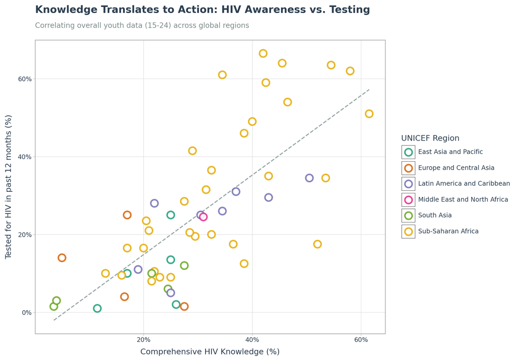

```python
# 1. Create a metadata dictionary for UNICEF regions
region_mapping = {
    "Sub-Saharan Africa": ["BDI", "BEN", "COG", "COM", "UGA", "NGA", "NAM", "ZAF", "KEN", "ETH", "TZA", "LSO", "MDG", "GAB", "GIN", "GMB", "GHA", "COD", "ZWE", "MWI", "MRI", "MRT", "RWA", "ZMB", "AGO", "MOZ", "BFA", "MLI", "SEN", "SLE", "STP", "SWZ", "TCD", "TGO", "SOM", "CIV", "CMR"],
    "South Asia": ["AFG", "BGD", "BTN", "IND", "MDV", "NPL", "PAK", "LKA"],
    "Middle East and North Africa": ["DZA", "BHR", "DJI", "EGY", "IRN", "IRQ", "JOR", "KWT", "LBN", "LBY", "MAR", "OMN", "QAT", "SAU", "SDN", "SYR", "TUN", "ARE", "YEM"],
    "Latin America and Caribbean": ["ARG", "BHS", "BRB", "BLZ", "BOL", "BRA", "CHL", "COL", "CRI", "CUB", "DOM", "ECU", "GUY", "SLV", "GTM", "HTI", "HND", "JAM", "MEX", "NIC", "PAN", "PRY", "PER", "URY", "VEN"],
    "East Asia and Pacific": ["AUS", "KHM", "CHN", "FJI", "IDN", "JPN", "KIR", "PRK", "KOR", "LAO", "MYS", "MHL", "FSM", "MNG", "MMR", "NRU", "NZL", "PLW", "PNG", "PHL", "WSM", "SGP", "SLB", "THA", "TLS", "TON", "TUV", "VUT", "VNM"],
    "Europe and Central Asia": ["ALB", "AND", "ARM", "AUT", "AZE", "BLR", "BEL", "BIH", "BGR", "HRV", "CYP", "CZE", "DNK", "EST", "FIN", "FRA", "GEO", "DEU", "GRC", "HUN", "ISL", "IRL", "ITA", "KAZ", "KGZ", "LVA", "LIE", "LTU", "LUX", "MLT", "MCO", "MNE", "NLD", "MKD", "NOR", "POL", "PRT", "MDA", "ROU", "RUS", "SMR", "SRB", "SVK", "SVN", "ESP", "SWE", "CHE", "TJK", "TUR", "TKM", "UKR", "GBR", "UZB"]
}

# 2. Flatten the dictionary into a list of tuples using list comprehension
metadata_rows = [(country, region) for region, countries in region_mapping.items() for country in countries]

# 3. Convert to a Polars DataFrame
region_mapping_df = pl.DataFrame(metadata_rows, schema=["alpha_3_code", "UNICEF_Region"], orient="row")

# 4. Join the region data with our previous combined data
hiv_knowledge_testing_data_final = combined_data.join(region_mapping_df, on="alpha_3_code", how="left")

# 5. Convert to pandas for plotnine
scatter_data_pd = hiv_knowledge_testing_data_final.to_pandas()

# 6. Build the Styled Scatterplot
scatter_plot = (
    ggplot(scatter_data_pd, aes(x="avg_hiv_knowledge", y="avg_hiv_testing")) +

    geom_smooth(method="lm", color="#95a5a6", linetype="dashed", size=0.8, se=False) +

    geom_point(aes(color="UNICEF_Region"), fill="white", size=4.5, alpha=0.85, stroke=1.2) +

    scale_x_continuous(labels=lambda l: [f"{v:.0%}" for v in l]) +
    scale_y_continuous(labels=lambda l: [f"{v:.0%}" for v in l]) +


    scale_color_brewer(type="qual", palette="Dark2") +

    theme_light() +
    labs(
        title="Knowledge Translates to Action: HIV Awareness vs. Testing",
        subtitle="Correlating overall youth data (15-24) across global regions",
        x="Comprehensive HIV Knowledge (%)",
        y="Tested for HIV in past 12 months (%)",
        color="UNICEF Region"
    ) +
    theme(
        figure_size=(10, 7),
        text=element_text(family="sans-serif", color="#2c3e50"),
        plot_title=element_text(weight="bold", size=14, margin={'b': 10}),
        plot_subtitle=element_text(size=10, color="#7f8c8d", margin={'b': 15}),
        panel_grid_minor=element_blank(),
        legend_position="right",
        legend_background=element_rect(fill="white", alpha=0)
    )
)

scatter_plot
```

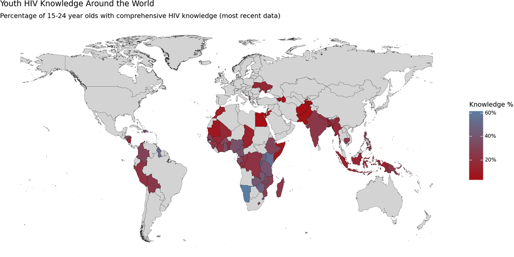

```python
# Create Youth HIV Knowledge Map Visualisation

# 1. Load world geometries from Natural Earth shapefile
world = gpd.read_file("https://public.opendatasoft.com/api/explore/v2.1/catalog/datasets/world-administrative-boundaries/exports/shp")

# 2. Merge with our data using ISO 3-letter codes
map_df = latest_avg_knowledge[['alpha_3_code', 'avg_hiv_knowledge']].to_pandas()
world_merged = world.merge(map_df, left_on="iso3", right_on="alpha_3_code", how="outer")
world = world[world.name != "Antarctica"]

# 3. Build the map with the custom gradient

world_map_red = (
    ggplot(world_merged)
    + geom_map(aes(fill="avg_hiv_knowledge"), color="black", size=0.1)
    + scale_fill_gradient(
        low="#a50f15",
        high="#5B7DA1",
        na_value="lightgrey",
        labels=lambda l: [f"{v:.0%}" for v in l]
        )
    + theme_void()
    + labs(
        title="Youth HIV Knowledge Around the World",
        subtitle="Percentage of 15-24 year olds with comprehensive HIV knowledge (most recent data)",
        fill="Knowledge %"
    )
    + theme(figure_size=(12, 6))
)

world_map_red
```